# Выбор модели для классификации пользователей TripAdvisor. Итерация 3

Alexey Shovkun

Tuesday, June 08, 2015

Итерация 3 - используем расширенный набор обучающих данных.

## Разведка исходных данных

Выделяем обучающую и тестовую выборки. Проверку качества модели в процессе подбора её параметров будем делать с использованием метода перекрестной проверки (cross validation) на обучающей выборке. Тестовая выборка будет использована **только** для оценки качества результирующей модели.

Размеры выборок:

- обучающая: 85 экземпляров.
- проверочная: отсутствует.
- тестовая: 28 экземпляров.

## Малоинформативные параметры

Проанализируем, какие параметры не несут информации (вариация равна 0, все значения одинаковы) или почти не несут информации (вариация близка к 0, большинство значений параметра одинаковы). Мы обязаны исключить их из рассмотрения при построении модели, т.к. в противном случае будут ошибки.

```
##                     freqRatio percentUnique zeroVar  nzv
## category10Percent       81.00      5.882353   FALSE TRUE
## category15Percent       82.00      4.705882   FALSE TRUE
## category10              27.00      3.529412   FALSE TRUE
## category15              41.00      3.529412   FALSE TRUE
## userRating10Percent     83.00      3.529412   FALSE TRUE
## userRating15Percent     84.00      2.352941   FALSE TRUE
## userRating20Percent     79.00      8.235294   FALSE TRUE
## userRating10            41.50      2.352941   FALSE TRUE
## userRating15            84.00      2.352941   FALSE TRUE
## tagVegetarian           41.50      2.352941   FALSE TRUE
## tagFashion              20.25      2.352941   FALSE TRUE
## tagNightLife            41.50      2.352941   FALSE TRUE
## tagSenior                0.00      1.176471    TRUE TRUE
## tagEco                  20.25      2.352941   FALSE TRUE
```

Перечисленные выше параметры не могут быть использованы для обучения модели. При сборе большего количества обучающих примеров, следует рассмотреть пользователей, у которых эти параметры не равны 0.

## Сокращение параметров

Мы обладаем небольшой обучающей выборкой, у которой количество параметров (features) сопоставимо или больше количества экземпляров. Для лучшего обучения некоторых моделей, нам стоит отобрать параметры:

- откинуть малоинформативные параметры с малой вариацией (см выше).
- отобрать наиболее информативные параметры генетическим алгоритмом.
- – откинуть параметры, которые сильно коррелируют между собой–.

## Обучение модели

Далее будем использовать следующе параметры пользователей:

```
##  [1] "class"                         "sex"
##  [3] "ageGroup"                      "reviews3Percent"
##  [5] "reviews5Percent"               "badgeHotelReviewsPercent"
##  [7] "badgeRestaurantReviewsPercent" "badgeFirstToReviewPercent"
##  [9] "badgeHotelReviewsCount"        "badgeTravellersChoiceCount"
## [11] "badgeAttractionReviewsCount"   "VIPBalanceCount"
## [13] "registrationYear"              "category25Percent"
## [15] "category35Percent"             "category45Percent"
## [17] "category30"                    "category35"
## [19] "category40"                    "userRating30Percent"
## [21] "userRating50Percent"           "userRating30"
## [23] "userRating35"                  "userRating40"
## [25] "tagBeach"                      "tagShopping"
## [27] "tagLuxury"                     "tagSilence"
## [29] "tagFamily"                     "tagArts"
## [31] "tagNone"
```

### Boosted Generalized Linear Model (glmboost)

Это продвинутый (boosted) вариант логистической регресии, один из самых базовых методов классификации, поэтому начнем с него. Модель строим на основе **всех параметров** пользователя, поскольку это, во-первых, дает немного лучшие результаты, а во-вторых, что самое важное, позволит нам получить альтернативный набор наиболее значимых параметров пользователя для построения других моделей.

```
## Boosted Generalized Linear Model
##
## 85 samples
## 76 predictors
##  2 classes: '0', '1'
##
## No pre-processing
## Resampling: Cross-Validated (10 fold)
##
## Summary of sample sizes: 77, 77, 76, 76, 78, 76, ...
##
## Resampling results across tuning parameters:
##
##   mstop  Accuracy   Kappa      Accuracy SD  Kappa SD
##    20    0.6839286  0.3228714  0.1450270    0.3132768
##    30    0.7343254  0.4308296  0.1478421    0.3235960
##    40    0.7232143  0.4101818  0.1658491    0.3554306
##    45    0.7565476  0.4768242  0.1340426    0.2987118
##    50    0.7579365  0.4874413  0.1401367    0.3032739
##    53    0.7565476  0.4768242  0.1340426    0.2987118
##    55    0.7565476  0.4768242  0.1340426    0.2987118
##    57    0.7565476  0.4768242  0.1340426    0.2987118
##    60    0.7468254  0.4656775  0.1520738    0.3274370
##    65    0.7579365  0.4874413  0.1401367    0.3032739
##    70    0.7468254  0.4656775  0.1520738    0.3274370
##    90    0.7468254  0.4655790  0.1427689    0.3080033
##   100    0.7343254  0.4332965  0.1568463    0.3429710
##   110    0.7357143  0.4413482  0.1444066    0.3101477
##   150    0.6898810  0.3457864  0.1784147    0.3780804
##   180    0.6644841  0.2980172  0.1566231    0.3332408
##   200    0.6755952  0.3235232  0.1519071    0.3219418
##   250    0.6755952  0.3235232  0.1519071    0.3219418
##   300    0.6505952  0.2701899  0.1063168    0.2278507
##   400    0.6505952  0.2747209  0.1295771    0.2683245
##   500    0.6380952  0.2530542  0.1248659    0.2597126
##
## Tuning parameter 'prune' was held constant at a value of no
## Accuracy was used to select the optimal model using  the largest value.
## The final values used for the model were mstop = 50 and prune = no.
```

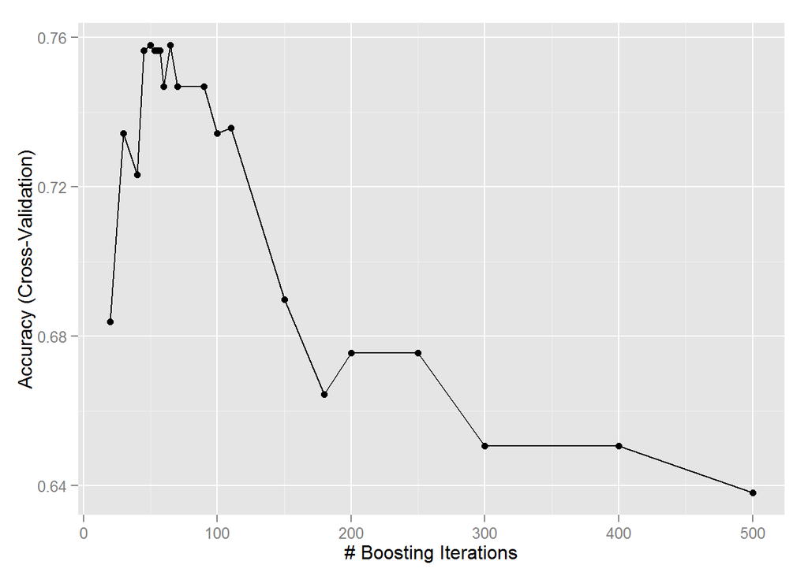

Несмотря на невысокую точность модели, проведем ее анализ с целью определить, какие параметры пользователя оказывали наибольшее влияние на результат.

```
## ROC curve variable importance
##
##   only 20 most important variables shown (out of 76)
##
##                            Importance
## category50                     100.00
## reviews5Percent                 98.61
## category50Percent               96.24
## badgeHotelReviewsPercent        94.96
## countriesCount                  93.03
## citiesCount                     91.63
## CPYCount                        89.81
## travelStatWorldPercent          88.30
## travelStatDistance              87.45
## badgeTravellersChoiceCount      78.33
## tagNone                         76.39
## tagLuxury                       73.82
## VIPBalanceCount                 69.53
## userRating50                    67.06
## userRating45                    66.52
## ageGroup                        58.05
## VIPBPYCount                     57.83
## badgeCitiesReviewsCount         54.94
## userRating40Percent             54.18
## userRating50Percent             53.97
```

Проведем анализ сдвига/разброса модели на основе Bossted GLM с параметрами:

- mstop = **50**,
- prune = **no**.

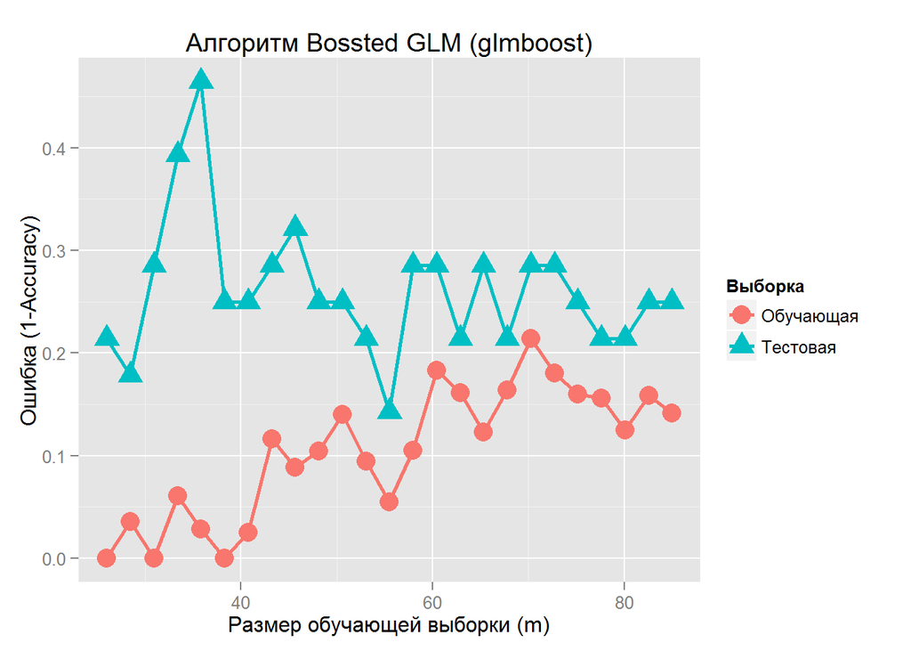

Из графика видим, что модель не страдает от переобучения и показанная ею точность в районе 75-80% является ее “нормальной” точностью (сдвигом) для заданных условий. Уменьшить сдвиг этой модели можно за счет:

- применения метода boosting (уже),
- добавления параметров пользователя.

Хотя логистическая регрессия в сложных задачах **может** давать не самую высокую точность предсказания, она неплохо работает в нашем случае, а также она позволяет неплохо выбрать наиболее значимые параметры пользователя для задачи классификации ВИП/не-ВИП. При обучении других более сложных моделей помимо отобранных ранее с помощью генетического алгоритма набора параметров будем также пробовать альтернативый набор, состоящий из 30-ти параметров, которые оказались наиболее информативными при построении логистической регрессии.

```
##  [1] "class"                         "category50"
##  [3] "reviews5Percent"               "category50Percent"
##  [5] "badgeHotelReviewsPercent"      "countriesCount"
##  [7] "citiesCount"                   "CPYCount"
##  [9] "travelStatWorldPercent"        "travelStatDistance"
## [11] "badgeTravellersChoiceCount"    "tagNone"
## [13] "tagLuxury"                     "VIPBalanceCount"
## [15] "userRating50"                  "userRating45"
## [17] "ageGroup"                      "VIPBPYCount"
## [19] "badgeCitiesReviewsCount"       "userRating40Percent"
## [21] "userRating50Percent"           "badgeHelpfulVotesCount"
## [23] "sex"                           "category00"
## [25] "badgeTotalReviewsCount"        "publicationsCount"
## [27] "badgeHotelReviewsCount"        "badgeAttractionReviewsPercent"
## [29] "badgeTotalReviewsTitle"        "userRating00Percent"
## [31] "tagFamily"
```

### Generalized Linear Model with Stepwise Feature Selection

```
## Generalized Linear Model with Stepwise Feature Selection
##
## 85 samples
## 30 predictors
##  2 classes: '0', '1'
##
## No pre-processing
## Resampling: Cross-Validated (10 fold)
##
## Summary of sample sizes: 77, 77, 76, 76, 78, 76, ...
##
## Resampling results
##
##   Accuracy   Kappa      Accuracy SD  Kappa SD
##   0.6621032  0.3167038  0.142845     0.3108869
##
##
```

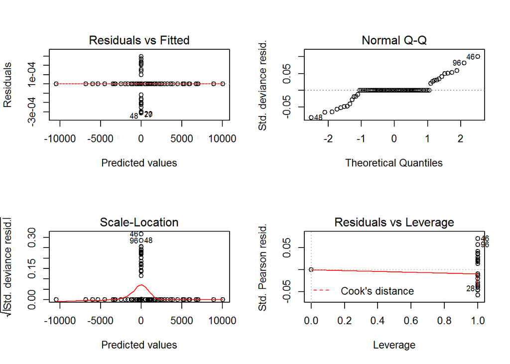

Результаты слабые, оценку разброса для модели делать не будем.

### Дерево решений (Decision Tree, rpart)

Применяем метод Cost-Sensitive Classification And Regression Tree (CART), чтобы иметь возможность противостоять потенциально высокому разбросу (переобучению) модели за счет параметра Cost.

```
## n= 85
##
## node), split, n, loss, yval, (yprob)
##       * denotes terminal node
##
## 1) root 85 36 1 (0.4235294 0.5764706)
##   2) badgeHotelReviewsPercent< 0.3159664 39 14 0 (0.6410256 0.3589744)
##     4) tagLuxury< 0.5 31  7 0 (0.7741935 0.2258065) *
##     5) tagLuxury>=0.5 8  1 1 (0.1250000 0.8750000) *
##   3) badgeHotelReviewsPercent>=0.3159664 46 11 1 (0.2391304 0.7608696) *
```

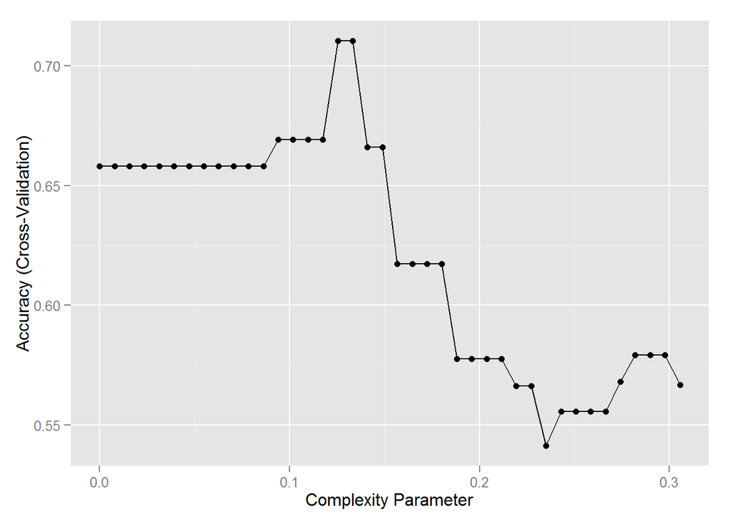

[figure not shown]

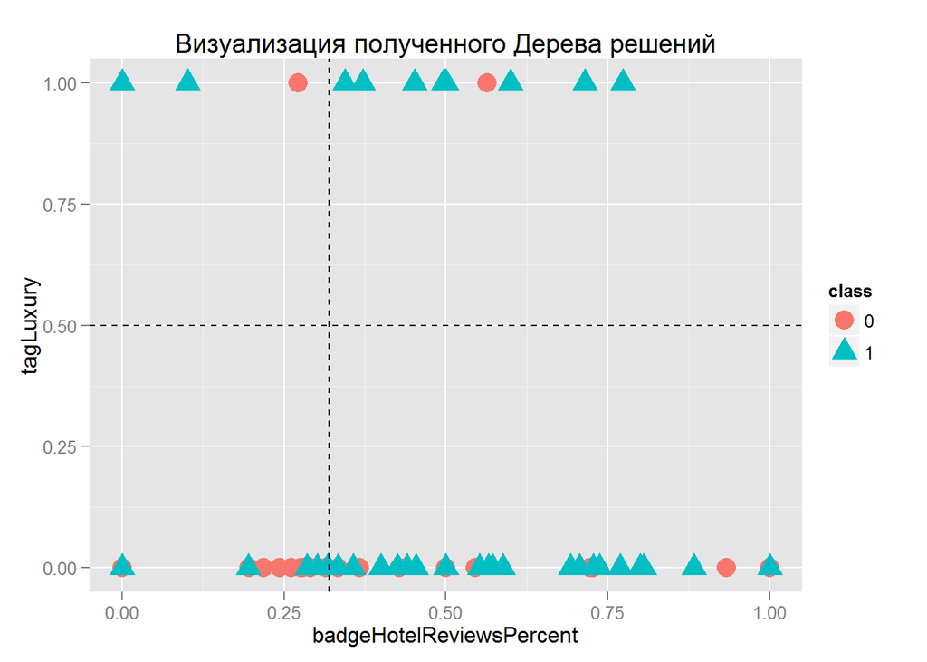

Получаем неплохую точность классификации пользователей ~70%, что несколько ниже точности продвинутой логистической регрессии (glmboost). Последний график показывает, что построенное дерево решений является не идеальной моделью.

Проведем анализ сдвига/разброса на основе Дерева решений c параметрами:

- minbucket = **5**,
- cp = **0.1331909**.

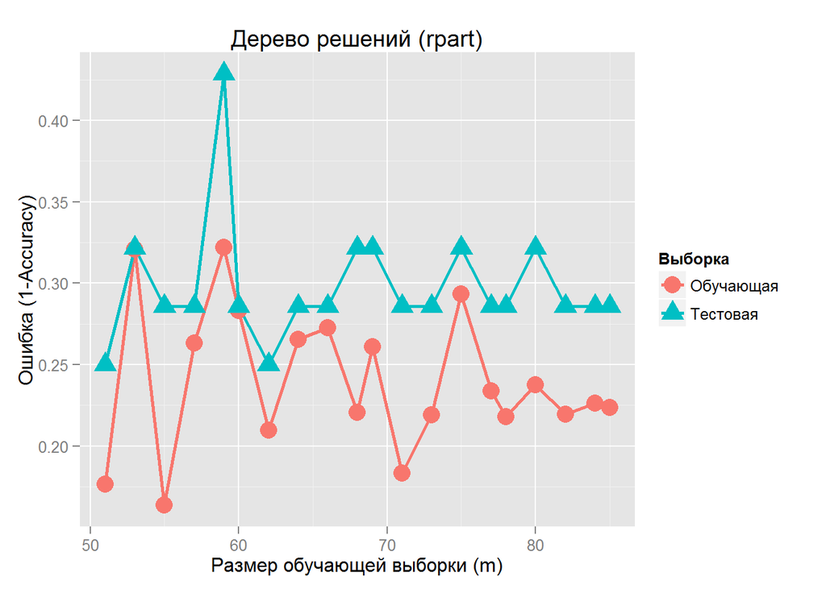

Этот график показывает низкий уровень разброса модели, поскольку графики сошлись. Соответственно, точность **~70%**, которую мы видим на графике для тестовой выборки при максимальных значениях её размера, является предельной для данной модели.

### Случайный лес (Random Forest, rf)

```
## Random Forest
##
## 85 samples
## 30 predictors
##  2 classes: '0', '1'
##
## No pre-processing
## Resampling: Cross-Validated (10 fold)
##
## Summary of sample sizes: 77, 77, 77, 76, 76, 76, ...
##
## Resampling results across tuning parameters:
##
##   mtry  Accuracy   Kappa      Accuracy SD  Kappa SD
##    2    0.7277778  0.4398871  0.1451006    0.3021281
##    3    0.7569444  0.4972537  0.1533030    0.3177760
##    6    0.7569444  0.4903489  0.1286754    0.2671886
##   11    0.7222222  0.4193840  0.1346578    0.2741387
##   12    0.6861111  0.3588436  0.1660482    0.3219232
##   16    0.6986111  0.3871770  0.1758101    0.3441674
##   21    0.6972222  0.3843497  0.1599468    0.3046047
##   31    0.6958333  0.3790451  0.1215134    0.2252532
##
## Accuracy was used to select the optimal model using  the largest value.
## The final value used for the model was mtry = 3.
```

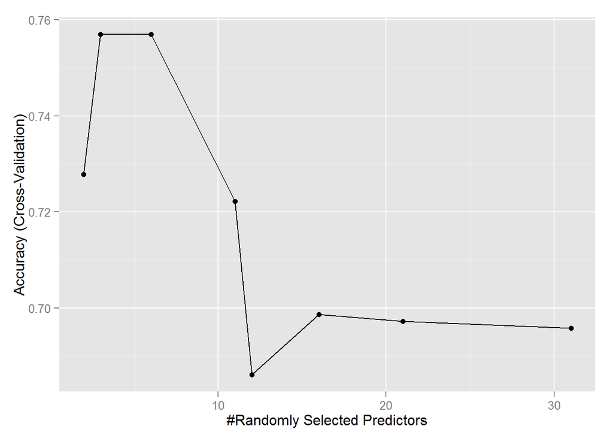

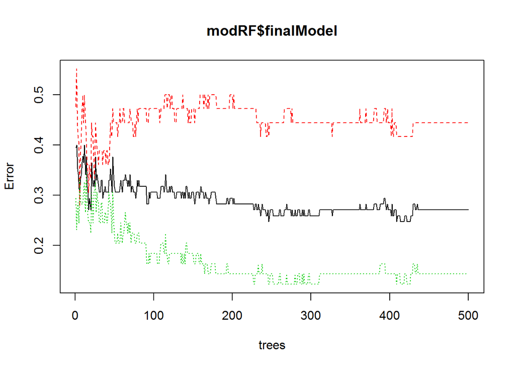

Проведем анализ сдвига/разброса на основе Случайного леса c параметром mtry =3.

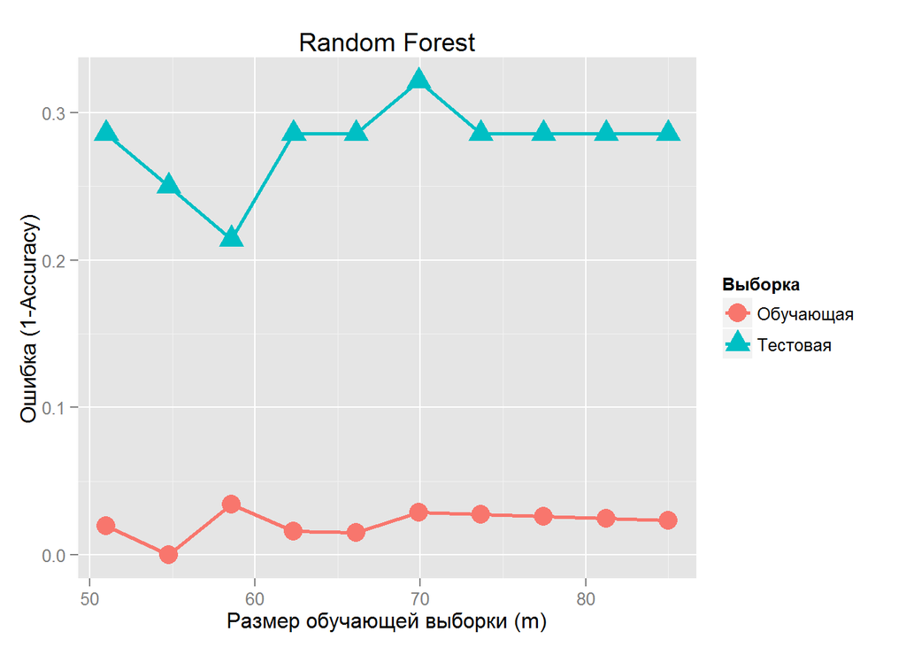

График показывает. что можель имеет высокий разброс, то есть переобучена. Чтобы побороть этот недостаток, можно применть следующее:

- регуляризация (см. далее),
- метод bagging,
- больше данных,
- сокращение (отбор) параметров.

### Случайный лес c регуляризацией (RRF)

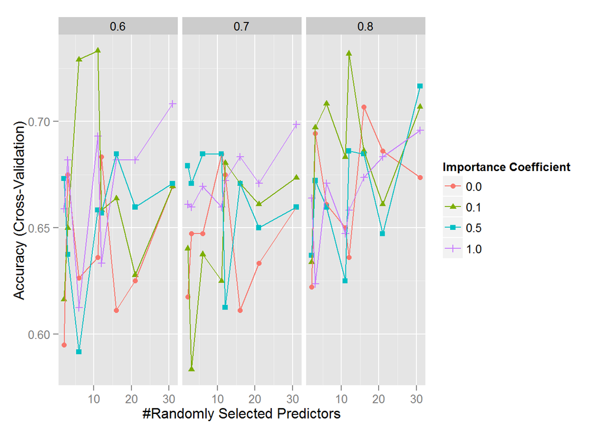

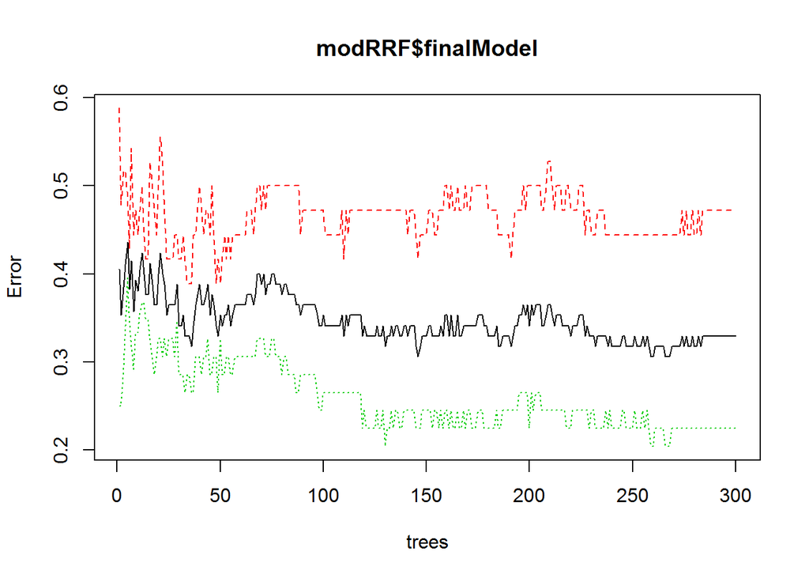

```
## RRF variable importance
##
##   only 20 most important variables shown (out of 35)
##
##                               Overall
## reviews5Percent                100.00
## userRating40                    48.09
## registrationYear                42.37
## category30                      42.29
## VIPBalanceCount                 35.17
## category45Percent               25.44
## tagNone                         21.15
## userRating30                     0.00
## badgeRestaurantReviewsPercent    0.00
## badgeTravellersChoiceCount       0.00
## category40                       0.00
## sexПол не известен               0.00
## badgeAttractionReviewsCount      0.00
## badgeFirstToReviewPercent        0.00
## tagSilence                       0.00
## tagBeach                         0.00
## tagShopping                      0.00
## category25Percent                0.00
## userRating50Percent              0.00
## category35Percent                0.00
```

```
## [1] 0.7333333
```

Проведем анализ сдвига/разброса Случайного леса с регуляризацией c параметрами:

- ntrees = **300**,
- mtry = **11**,
- coefReg = **0.6**,
- coefImp = **0.1**.

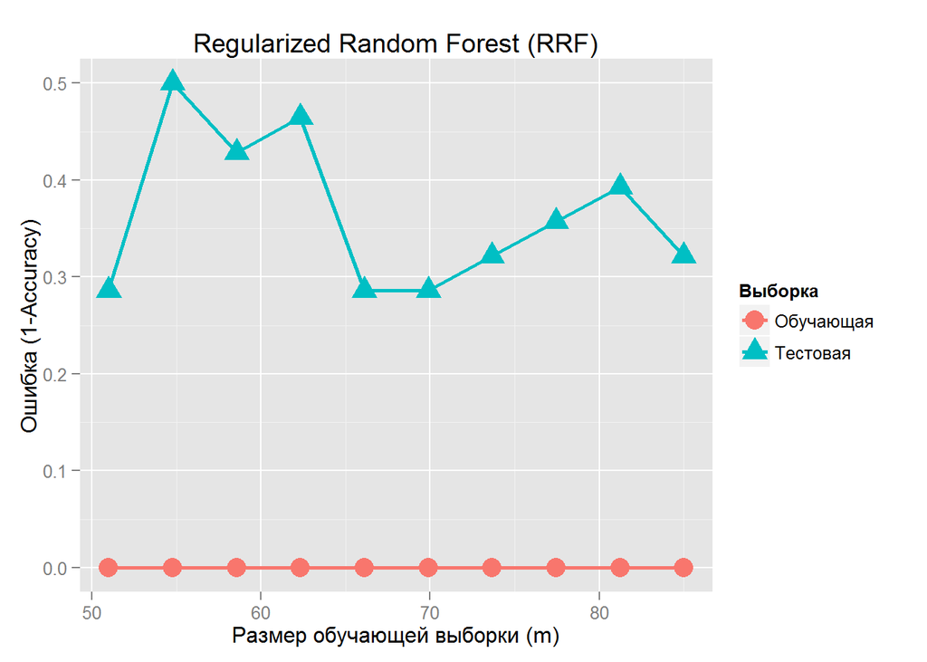

График показывает, что модель имеет высокий разброс, то есть переобучена.

### LogitBoost Classification Algorithm (Boosted Logistic Regression)

Train logitboost classification algorithm using decision stumps (one node decision trees) as weak learners.

```
## Boosted Logistic Regression
##
## 85 samples
## 30 predictors
##  2 classes: '0', '1'
##
## No pre-processing
## Resampling: Cross-Validated (10 fold)
##
## Summary of sample sizes: 77, 77, 76, 76, 78, 76, ...
##
## Resampling results across tuning parameters:
##
##   nIter  Accuracy   Kappa      Accuracy SD  Kappa SD
##    10    0.7604762  0.5199337  0.1839908    0.3698239
##    20    0.7604762  0.5024417  0.1992149    0.3882866
##    30    0.6940476  0.3652162  0.1636201    0.3146440
##    40    0.6303571  0.2307827  0.1859679    0.3776803
##    45    0.6394841  0.2769780  0.1452591    0.2979825
##    50    0.6667857  0.2717932  0.1504805    0.3687019
##    53    0.6871032  0.3674789  0.1355644    0.2795180
##    55    0.6398810  0.2822955  0.1401094    0.2813902
##    57    0.6621032  0.3285708  0.1328955    0.2595986
##    60    0.7228175  0.4332145  0.2046593    0.4308870
##    65    0.6746032  0.3559235  0.1647795    0.3146601
##    70    0.6801587  0.3608336  0.1520497    0.3008450
##    90    0.6869048  0.3689938  0.1836715    0.3615663
##   100    0.6878968  0.3791142  0.1802392    0.3417442
##   110    0.6954365  0.3942955  0.1765446    0.3296562
##   150    0.6730159  0.3580304  0.1981078    0.3782105
##   200    0.6932540  0.3794099  0.1990405    0.3973740
##   250    0.6916667  0.3759954  0.1644399    0.3336865
##   300    0.6972222  0.3857515  0.1558749    0.3194240
##   400    0.6751984  0.3414694  0.1417199    0.3016622
##   500    0.6912698  0.3750524  0.1551238    0.3223324
##
## Accuracy was used to select the optimal model using  the largest value.
## The final value used for the model was nIter = 10.
```

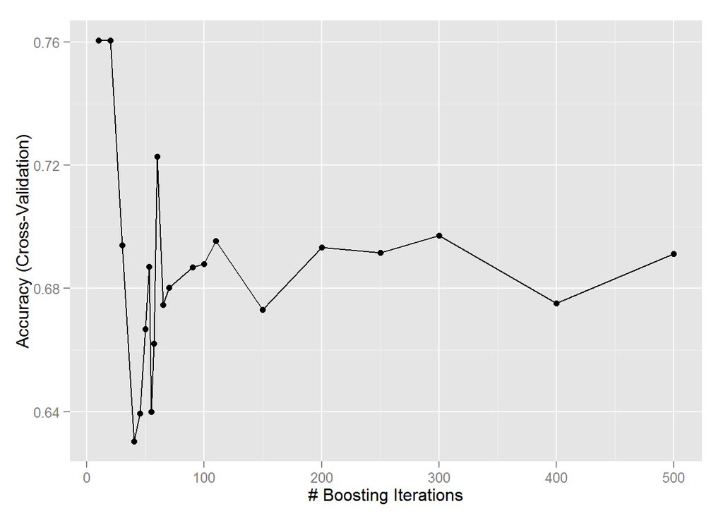

Проведем анализ сдвига/разброса на основе LogitBoost c параметром nIter =10.

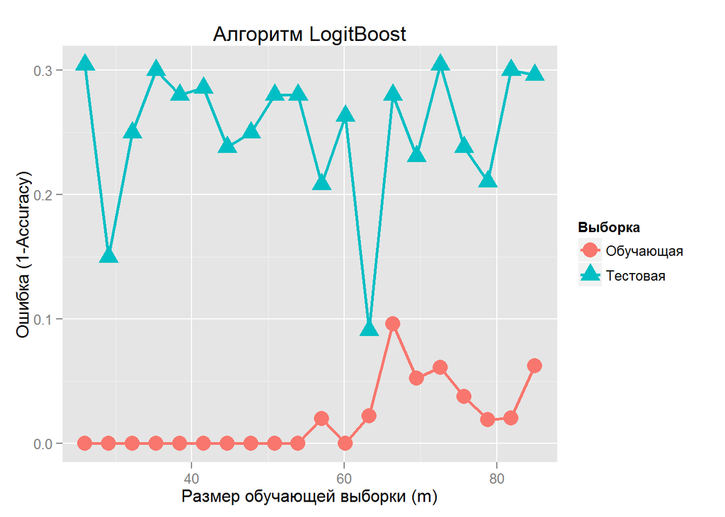

Модель показывает довольно высокий уровень разброса.

### Продвинутое (boosted) Дерево решений (C5.0)

Предыдущий метод использовал набор одноуровневых деревьев для коллективного голосования, сейчас мы будем использовать сборку из многоуровневых деревьев.

```
##
## Call:
## C5.0.default(x = structure(c(0.0433437367425095, 0, 0,
##  "bands", "winnow", "noGlobalPruning", "CF", "minCases",
##  "fuzzyThreshold", "sample", "earlyStopping", "label", "seed")))
##
## Classification Tree
## Number of samples: 85
## Number of predictors: 35
##
## Number of boosting iterations: 80
## Average tree size: 9.8
##
## Non-standard options: attempt to group attributes
```

```
## C5.0 variable importance
##
##   only 20 most important variables shown (out of 37)
##
##                               Overall
## VIPBalanceCount                   100
## reviews5Percent                   100
## badgeAttractionReviewsPercent     100
## badgeTotalReviewsCount            100
## badgeTravellersChoiceCount        100
## tagNone                           100
## category50                        100
## userRating00Percent               100
## ageGroup50-64                     100
## userRating50                      100
## category50Percent                 100
## tagFamily                         100
## sexмужчина                        100
## badgeHotelReviewsPercent          100
## tagLuxury                         100
## travelStatWorldPercent            100
## badgeTotalReviewsTitle            100
## ageGroup35-49                     100
## badgeCitiesReviewsCount           100
## travelStatDistance                100
```

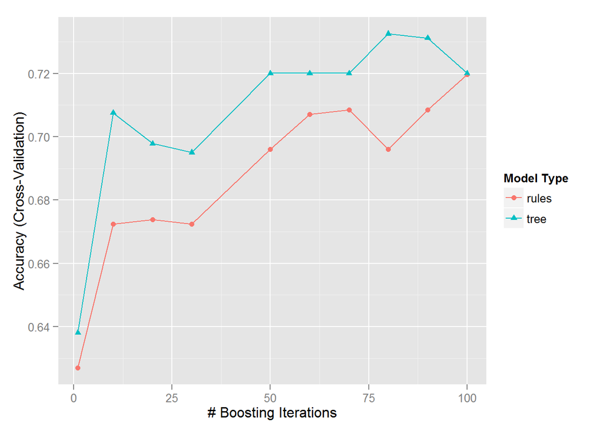

```
## [1] 0.7325397
```

Проведем анализ сдвига/разброса для Продвинутого дерева решений (C5.0):

- model = **tree**,
- winnow = **FALSE**,
- trials = **80**.

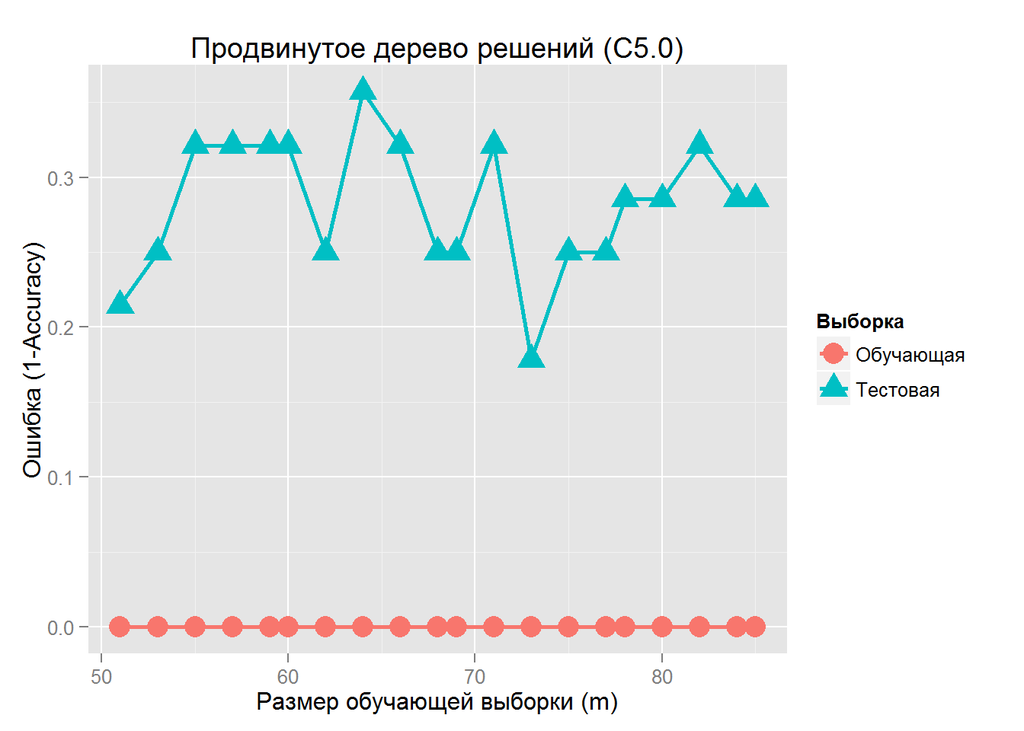

Модель переобучена.

### Stochastic Gradient Boosting, ~AdaBoost (gbm)

An implementation of extensions to Freund and Schapire’s AdaBoost algorithm and Friedman’s gradient boosting machine. Includes regression methods for least squares, absolute loss, t-distribution loss, quantile regression, logistic, multinomial logistic, Poisson, Cox proportional hazards partial likelihood, AdaBoost exponential loss, Huberized hinge loss, and Learning to Rank measures (LambdaMart). http://en.wikipedia.org/wiki/Gradient_boosting

Параметры модели:

- **n.minobsinnode** - minimum total weight needed in each node.It is used in the tree building process by ignoring any splits that lead to nodes containing fewer than this number of training set instances.
- **n.trees** - количество деревьев, которые будут построены.
- **interaction.depth** - the maximum depth of variable interactions. 1 implies an additive model, 2 implies a model with up to 2-way interactions, etc.

```
##    user  system elapsed
##    1.68    0.11  110.86
```

```
## A gradient boosted model with bernoulli loss function.
## 1000 iterations were performed.
## There were 35 predictors of which 26 had non-zero influence.
```

```
## gbm variable importance
##
##   only 20 most important variables shown (out of 35)
##
##                               Overall
## badgeHotelReviewsPercent      100.000
## reviews5Percent                90.916
## badgeFirstToReviewPercent      62.885
## userRating50Percent            45.380
## badgeTravellersChoiceCount     42.368
## badgeHotelReviewsCount         36.672
## category30                     28.690
## VIPBalanceCount                28.534
## userRating30Percent            27.995
## userRating40                   27.784
## tagNone                        26.300
## tagLuxury                      24.194
## reviews3Percent                23.497
## registrationYear               21.129
## ageGroupВозраст не известен    18.300
## badgeRestaurantReviewsPercent  17.176
## category40                     14.525
## userRating35                   12.158
## category45Percent               9.761
## sexмужчина                      7.724
```

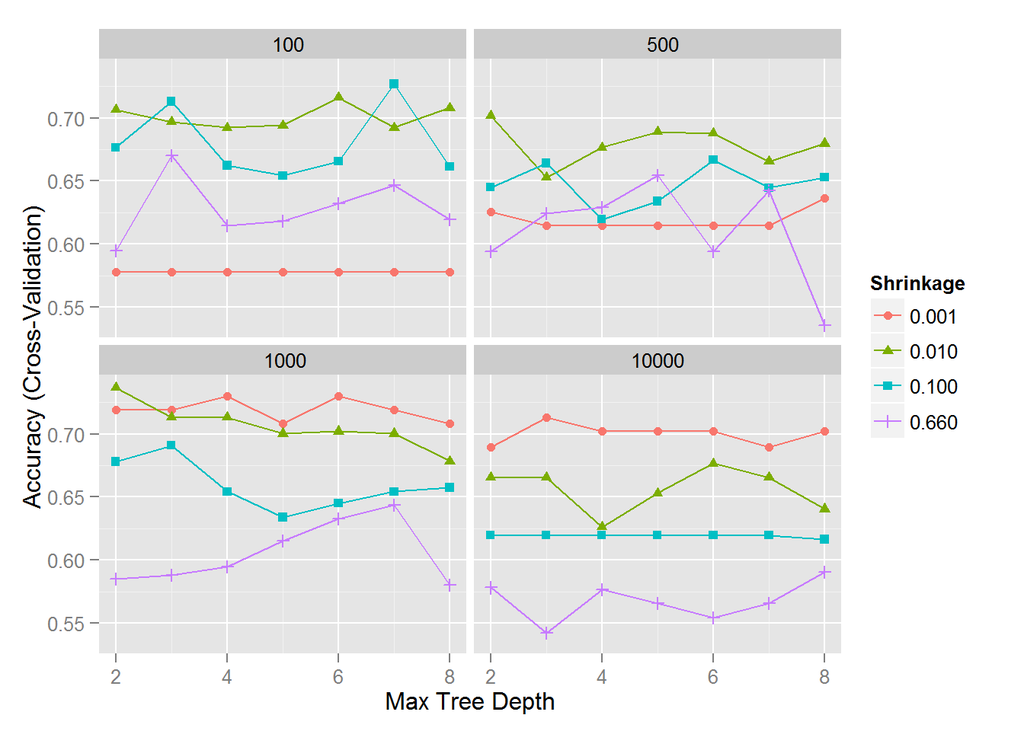

Из графика видим, что при достаточно большом количестве деревьев (1000 и выше), лучше всего работает маленькое значение параметра скорости обучения (shrinkage = 0.001). Также из графика видно, что модель дает высокую точность при небольших значениях количества деревьев и больших значениях скорости обучения. Скорее всего, это из-за переобученя, поэтому не будем полагаться на автоматически выбранную “лучшую” модель, а возьмем более обученную с большим количеством деревьев и меньшей скоростью обучения, а параметр interaction.depth пусть будет выбран атоматически.

```
##    user  system elapsed
##    1.44    0.11   15.48
```

```
## Stochastic Gradient Boosting
##
## 85 samples
## 30 predictors
##  2 classes: '0', '1'
##
## No pre-processing
## Resampling: Cross-Validated (10 fold)
##
## Summary of sample sizes: 76, 76, 77, 77, 78, 77, ...
##
## Resampling results across tuning parameters:
##
##   shrinkage  interaction.depth  Accuracy   Kappa      Accuracy SD
##   0.001      2                  0.7047619  0.3475117  0.13277617
##   0.001      3                  0.7079365  0.3564825  0.14055999
##   0.001      4                  0.7190476  0.3806289  0.13125999
##   0.001      5                  0.7079365  0.3564825  0.14055999
##   0.001      6                  0.7079365  0.3576364  0.11945770
##   0.001      7                  0.7079365  0.3564825  0.14055999
##   0.001      8                  0.7190476  0.3807133  0.14132470
##   0.010      2                  0.7144841  0.3866299  0.14946051
##   0.010      3                  0.7130952  0.3853777  0.14329494
##   0.010      4                  0.7130952  0.3897733  0.16576454
##   0.010      5                  0.6783730  0.3219046  0.17856518
##   0.010      6                  0.7130952  0.3841631  0.12266406
##   0.010      7                  0.6876984  0.3391817  0.17750810
##   0.010      8                  0.7130952  0.3897733  0.16576454
##   0.100      2                  0.6103175  0.1942716  0.14516314
##   0.100      3                  0.6686508  0.3161625  0.08039456
##   0.100      4                  0.6279762  0.2277347  0.16527313
##   0.100      5                  0.6464286  0.2693338  0.13033229
##   0.100      6                  0.6418651  0.2579219  0.13290607
##   0.100      7                  0.6561508  0.2755086  0.15389758
##   0.100      8                  0.6811508  0.3372516  0.09395749
##   Kappa SD
##   0.2957303
##   0.3105244
##   0.2974784
##   0.3105244
##   0.2706228
##   0.3105244
##   0.3157048
##   0.3364748
##   0.3365064
##   0.3716325
##   0.3938079
##   0.2986126
##   0.3900244
##   0.3716325
##   0.3099432
##   0.1878112
##   0.3491951
##   0.2709364
##   0.2917109
##   0.3536958
##   0.2091194
##
## Tuning parameter 'n.trees' was held constant at a value of 1000
## Accuracy was used to select the optimal model using  the largest value.
## The final values used for the model were n.trees = 1000,
##  interaction.depth = 4 and shrinkage = 0.001.
```

```
## gbm variable importance
##
##   only 20 most important variables shown (out of 35)
##
##                               Overall
## badgeHotelReviewsPercent      100.000
## reviews5Percent                73.886
## userRating50Percent            19.996
## badgeFirstToReviewPercent      17.559
## tagNone                        17.147
## userRating30Percent            15.064
## badgeTravellersChoiceCount     14.806
## tagLuxury                      12.559
## category30                     12.485
## ageGroupВозраст не известен    11.340
## VIPBalanceCount                10.869
## badgeHotelReviewsCount          7.242
## userRating40                    6.477
## reviews3Percent                 6.288
## badgeRestaurantReviewsPercent   4.086
## userRating35                    2.243
## registrationYear                2.192
## category45Percent               1.616
## sexПол не известен              1.515
## ageGroup35-49                   1.196
```

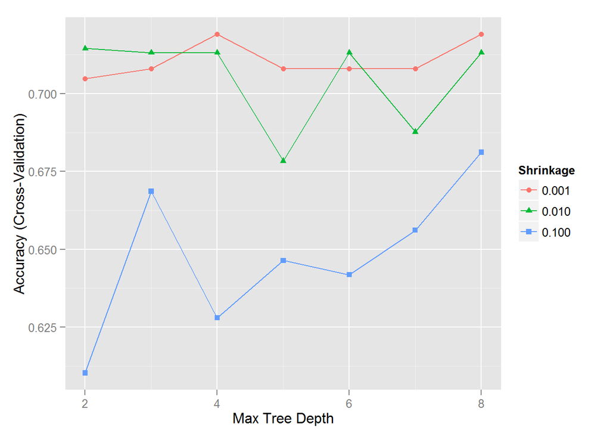

Видим, что вручную подобранная модель использует большее количество параметров пользователя.

Проведем анализ сдвига/разброса на основе Stochastic Gradient Boosting c параметрами: - n.minobsinnode = *11*, - n.trees = **1000**, - interaction.depth = **4**, - shrinkage = **0.001**.

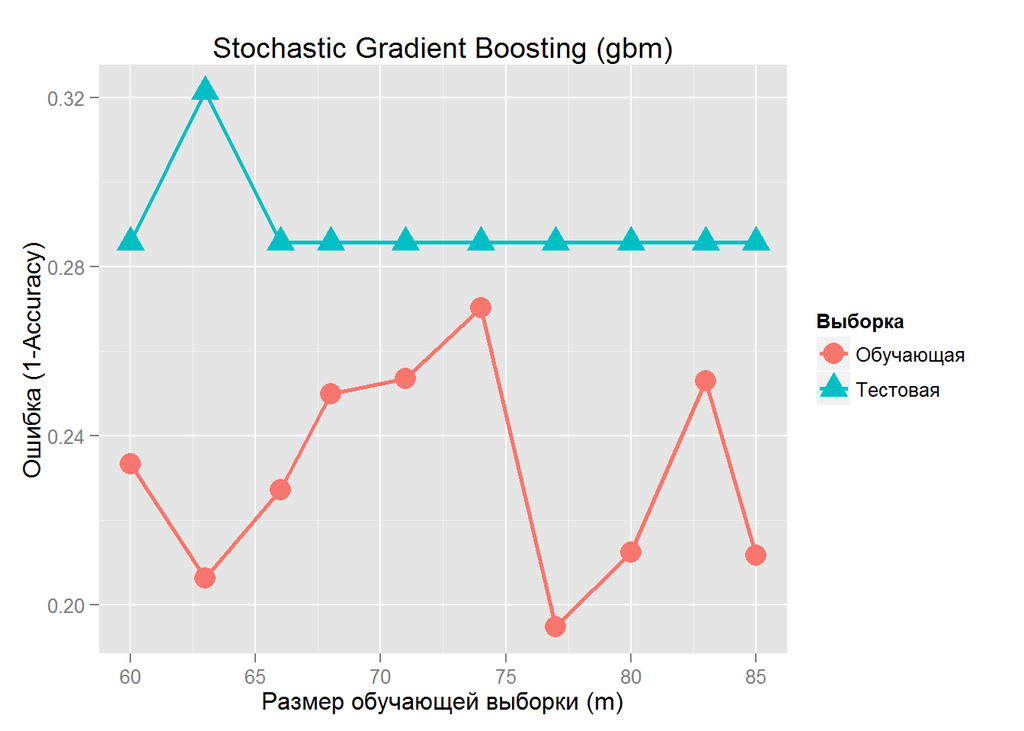

### Метод опорных векторов (Support Vector Machine)

Известно, что для задач классификации лучше подходит ядро на снове радиальной базисной функции или полиномиальное ядро, нежели чем линейное ядро. Тесты показывют, что лучще всегоработает полиномиальное ядро, затем идут RBF и линейное ядра. Используем полиномиальное ядро.

```
## Support Vector Machines with Polynomial Kernel
##
## 85 samples
## 30 predictors
##  2 classes: '0', '1'
##
## No pre-processing
## Resampling: Cross-Validated (10 fold)
##
## Summary of sample sizes: 77, 77, 77, 76, 76, 76, ...
##
## Resampling results across tuning parameters:
##
##   degree  scale  C     Accuracy   Kappa        Accuracy SD  Kappa SD
##    2      0.01   0.01  0.5777778   0.00000000  0.04401802   0.00000000
```

[output cut: 65 more lines]

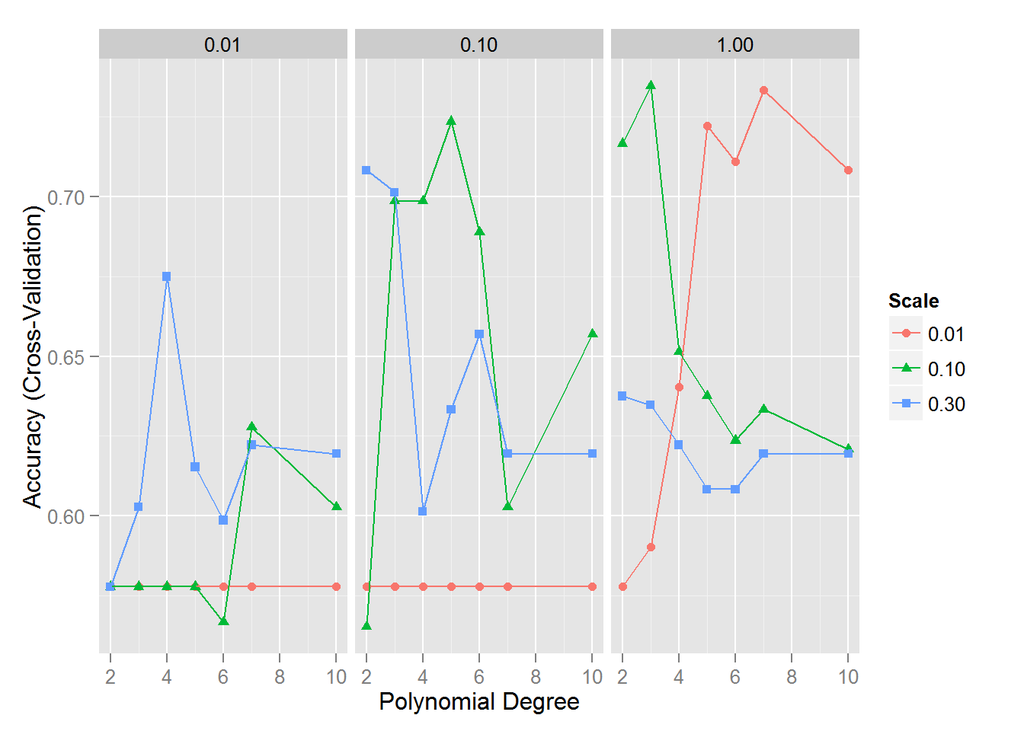

Проведем анализ сдвига/разброса на основе модели SVM c параметрами:

- degree = 3
- scale = 0.1
- С =1

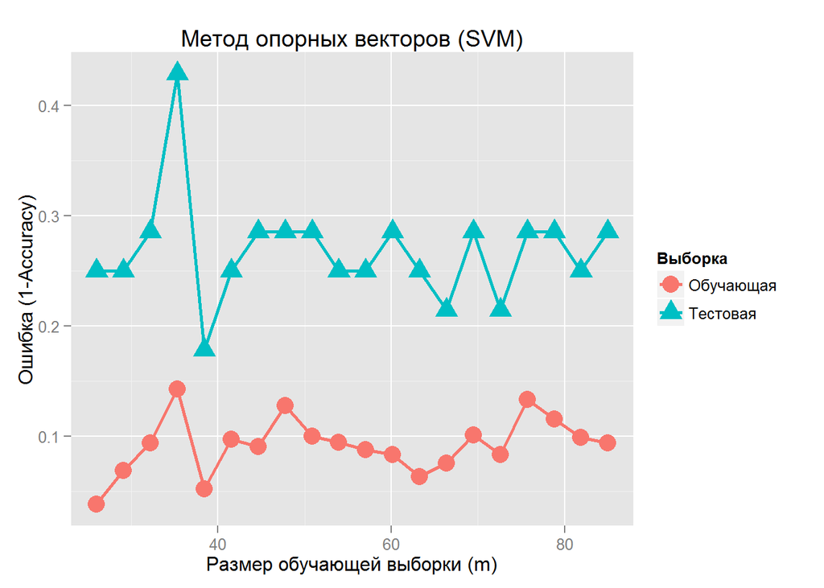

### Нейросеть с 1 уровнем (nnet)

Можно применить нейросеть с предварительным отбором параметров на основе метода главных компонент (pcaNNet), но мы уже отобрали наиборлее информативные параметры, поэтому используем обычную одноуровневую нейросеть (nnet).

```
##    user  system elapsed
##    1.70    0.08   13.76
```

```
## Neural Network
##
## 85 samples
## 30 predictors
##  2 classes: '0', '1'
##
## No pre-processing
## Resampling: Cross-Validated (10 fold)
##
## Summary of sample sizes: 76, 76, 76, 77, 77, 77, ...
##
## Resampling results across tuning parameters:
##
##   decay  size  Accuracy   Kappa      Accuracy SD  Kappa SD
##   0.010   3    0.6000000  0.1801339  0.1183593    0.2466292
##   0.010   4    0.6555556  0.2932672  0.1241915    0.2728186
##   0.010   5    0.6458333  0.2569196  0.1776536    0.3994050
##   0.010   6    0.6444444  0.2632047  0.1167915    0.2632105
##   0.010   7    0.6805556  0.3478751  0.1141558    0.2381201
##   0.010   8    0.6833333  0.3418753  0.1628682    0.3431524
##   0.010  10    0.6569444  0.2945118  0.1560467    0.3299177
##   0.033   3    0.7152778  0.4129653  0.1646287    0.3480602
##   0.033   4    0.6944444  0.3802461  0.1408808    0.2988178
##   0.033   5    0.7041667  0.3953927  0.1008048    0.2142338
##   0.033   6    0.7055556  0.3869378  0.1989987    0.4247625
##   0.033   7    0.7069444  0.3962236  0.1724125    0.3650976
##   0.033   8    0.7180556  0.4216082  0.1564582    0.3297127
##   0.033  10    0.7180556  0.4168714  0.1324187    0.2907618
##   0.100   3    0.7416667  0.4641230  0.1219975    0.2575540
##   0.100   4    0.7402778  0.4612842  0.1231951    0.2624811
##   0.100   5    0.7291667  0.4393611  0.1128813    0.2422809
##   0.100   6    0.7416667  0.4643611  0.1219975    0.2613787
##   0.100   7    0.7291667  0.4393611  0.1128813    0.2422809
##   0.100   8    0.7277778  0.4416764  0.1283335    0.2641448
##   0.100  10    0.7402778  0.4612842  0.1231951    0.2624811
##   0.330   3    0.7527778  0.4898701  0.1736944    0.3484783
##   0.330   4    0.7527778  0.4898701  0.1736944    0.3484783
##   0.330   5    0.7527778  0.4898701  0.1736944    0.3484783
##   0.330   6    0.7527778  0.4898701  0.1736944    0.3484783
##   0.330   7    0.7527778  0.4898701  0.1736944    0.3484783
##   0.330   8    0.7527778  0.4898701  0.1736944    0.3484783
##   0.330  10    0.7402778  0.4548701  0.2054899    0.4373015
##   0.900   3    0.7083333  0.3498726  0.1307819    0.3020727
##   0.900   4    0.7083333  0.3498726  0.1307819    0.3020727
##   0.900   5    0.7083333  0.3498726  0.1307819    0.3020727
##   0.900   6    0.7208333  0.3748726  0.1278734    0.3032317
##   0.900   7    0.7208333  0.3748726  0.1278734    0.3032317
##   0.900   8    0.7208333  0.3748726  0.1278734    0.3032317
##   0.900  10    0.7333333  0.4078396  0.1368367    0.3217630
##
## Accuracy was used to select the optimal model using  the largest value.
## The final values used for the model were size = 3 and decay = 0.33.
```

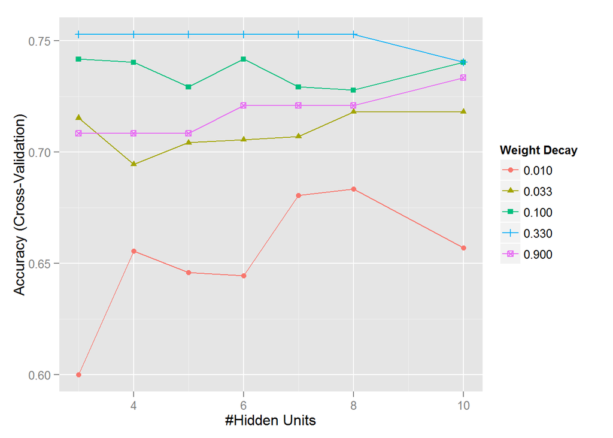

```
## nnet variable importance
##
##   only 20 most important variables shown (out of 35)
##
##                               Overall
## tagLuxury                      100.00
## badgeTravellersChoiceCount      99.40
## reviews5Percent                 95.89
## category50Percent               92.73
## ageGroupВозраст не известен     75.72
## badgeHotelReviewsPercent        75.20
## sexмужчина                      47.08
## ageGroup25-34                   46.77
## citiesCount                     46.49
## CPYCount                        44.87
## badgeTotalReviewsTitle          44.74
## userRating40Percent             41.03
## badgeAttractionReviewsPercent   35.03
## tagNone                         30.98
## publicationsCount               27.39
## badgeTotalReviewsCount          22.09
## tagFamily                       21.96
## userRating45                    21.89
## countriesCount                  21.54
## travelStatDistance              21.30
```

Проведем анализ полноты обучения для полученной нейросети nnet с параметрами:

- maxit = **5000**,
- size = **3**,
- decay = **0.33**.

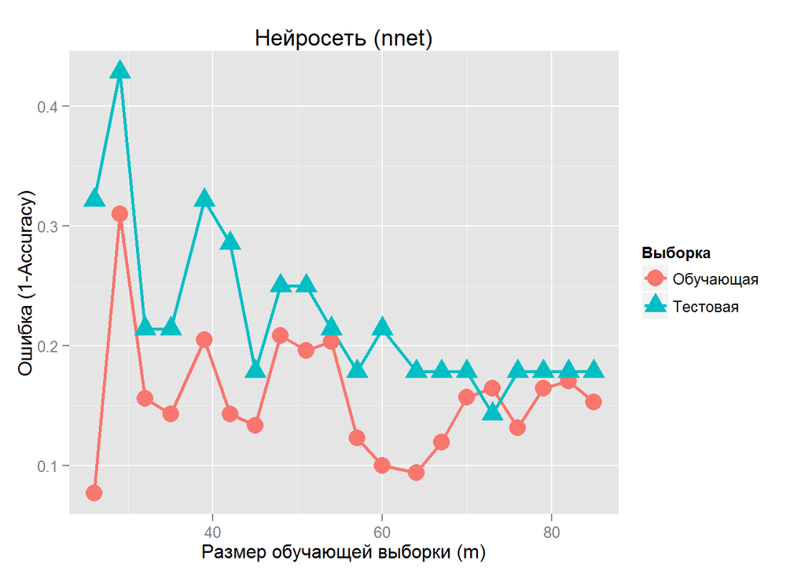

### Model Averaged Neural Network (nnet)

При данном подходе нейросеть обучается несколько раз для разных начальных значений счетчика случайных чисел. Предсказанные результаты усредняются. Following Ripley (1996), the same neural network model is fit using different random number seeds. All the resulting models are used for prediction. For regression, the output from each network are averaged. For classification, the model scores are first averaged, then translated to predicted classes. Bagging can also be used to create the models.

Всегда чуть хуже, чем предыдущая нейросеть. Рассчет отключен для экономии времени.

### Multi Layer Perceptron (RSNNS)

```
##    user  system elapsed
##    2.23    0.05   20.01
```

```
## Multi-Layer Perceptron
##
## 85 samples
## 30 predictors
##  2 classes: '0', '1'
##
## No pre-processing
## Resampling: Cross-Validated (10 fold)
##
## Summary of sample sizes: 76, 76, 76, 77, 77, 77, ...
##
## Resampling results across tuning parameters:
##
##   size  Accuracy   Kappa      Accuracy SD  Kappa SD
##    2    0.7430556  0.4775047  0.1877428    0.3858640
##    3    0.7041667  0.3925346  0.1503098    0.3160835
##    4    0.7305556  0.4461074  0.1531561    0.3100699
##    5    0.7513889  0.4916104  0.1054601    0.2118105
##    6    0.7305556  0.4335879  0.1387654    0.3086854
##    7    0.7291667  0.4550733  0.1516160    0.2915957
##    8    0.7263889  0.4515979  0.1669301    0.3383783
##   10    0.7041667  0.3812589  0.1910024    0.4218437
##   12    0.7027778  0.3850415  0.1723814    0.3588787
##   15    0.6833333  0.3533441  0.1829495    0.3869601
##
## Accuracy was used to select the optimal model using  the largest value.
## The final value used for the model was size = 5.
```

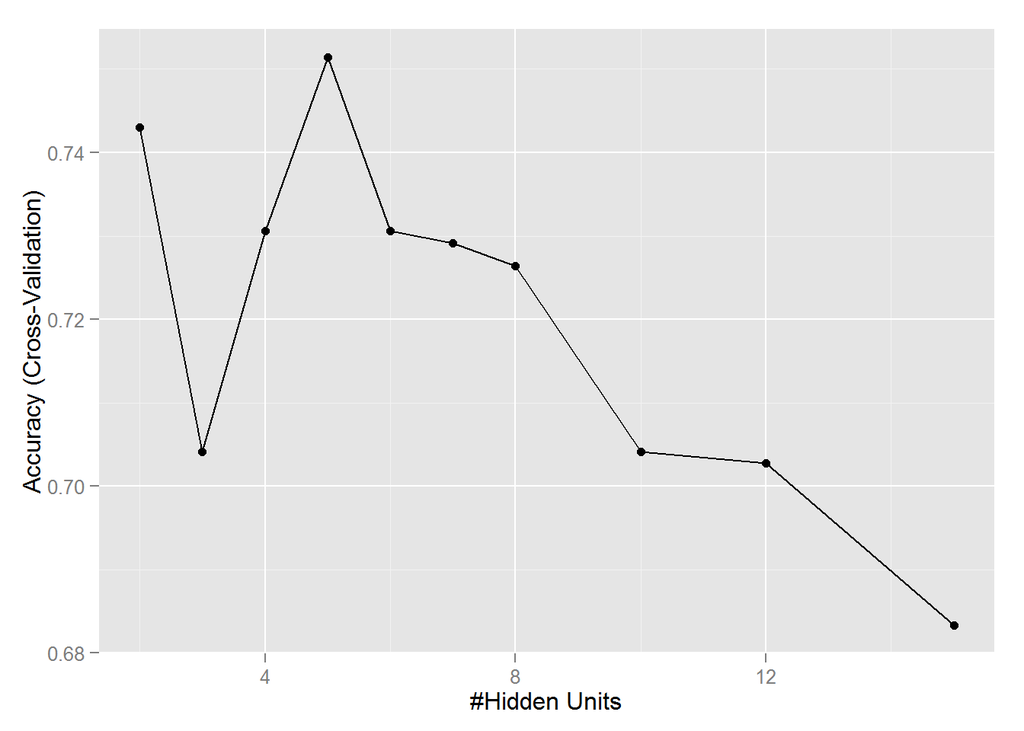

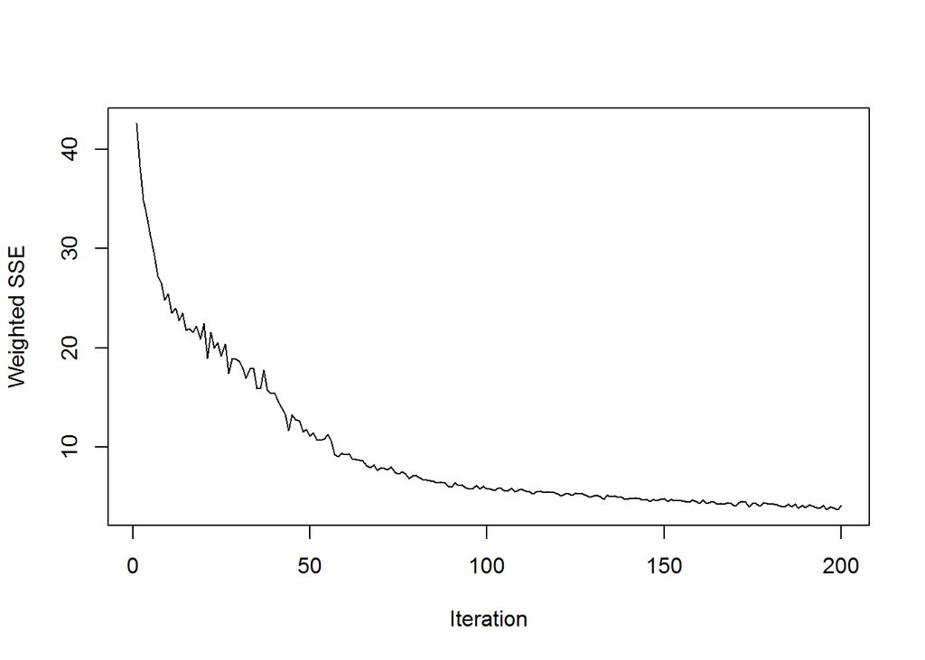

```
## ROC curve variable importance
##
##   only 20 most important variables shown (out of 30)
##
##                            Importance
## category50                     100.00
## reviews5Percent                 97.39
## category50Percent               92.99
## badgeHotelReviewsPercent        90.58
## countriesCount                  86.97
## citiesCount                     84.37
## CPYCount                        80.96
## travelStatWorldPercent          78.16
## travelStatDistance              76.55
## badgeTravellersChoiceCount      59.52
## tagNone                         55.91
## tagLuxury                       51.10
## VIPBalanceCount                 43.09
## userRating50                    38.48
## userRating45                    37.47
## ageGroup                        21.64
## VIPBPYCount                     21.24
## badgeCitiesReviewsCount         15.83
## userRating40Percent             14.43
## userRating50Percent             14.03
```

Последний график, показывает, что при увеличении количества итераций ошибка стремится к 0, т.е. модель склонна к переобучению. Ограничим число итераций по правилю “клюшки” 200 итерациями.

Проведем анализ полноты обучения для полученной нейросети RSNNS с параметрами:

- maxit = 200.
- learnFunc = BackpropMomentum.
- learnFuncParams = c(0.1, 0.03, 0.1, 0.001).
- hiddenActFunc = Act_TanH.
- size = 5.

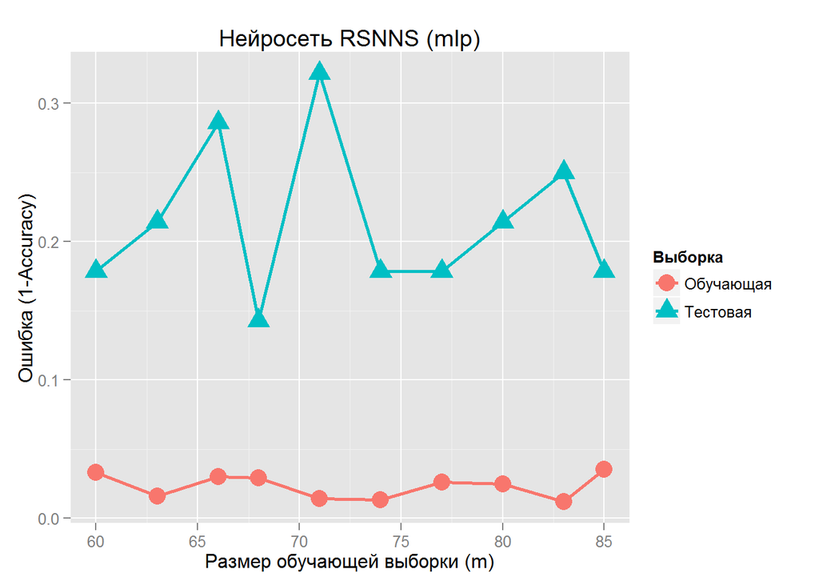

Модель показывает неплохую точность на тестовой выборке, однако разброс довольно велик.

### Анализ качества обученных моделей

[output not shown]

Для моделей, которые показали хорошие резулььтаты (низкий разброс), проанализируем ROC кривые.

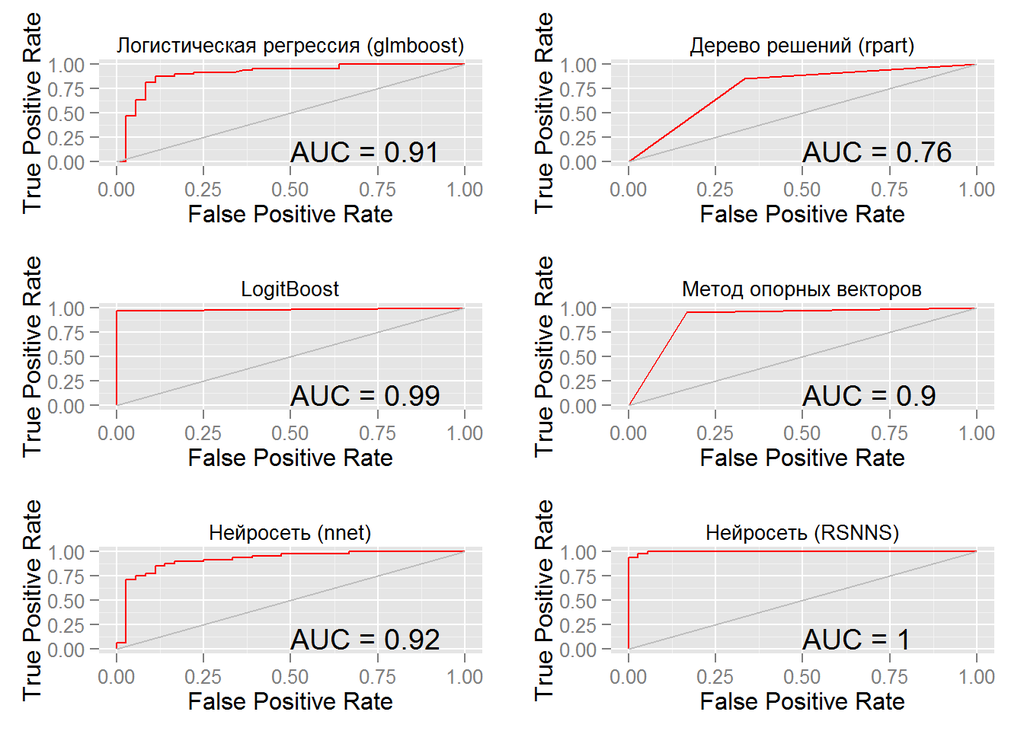

В качестве финальной лучшей модели выберем **Нейросеть nnet**, которая показывает низкий уровень разброса при очень хорошем значении AUC.

### Проверка лучшей модели на тестовой выборке

```
## Confusion Matrix and Statistics
##
##           Reference
## Prediction  0  1
##          0  9  2
##          1  3 14
##
##                Accuracy : 0.8214
##                  95% CI : (0.6311, 0.9394)
##     No Information Rate : 0.5714
##     P-Value [Acc > NIR] : 0.004922
##
##                   Kappa : 0.6316
##  Mcnemar's Test P-Value : 1.000000
##
##             Sensitivity : 0.8750
##             Specificity : 0.7500
##          Pos Pred Value : 0.8235
##          Neg Pred Value : 0.8182
##              Prevalence : 0.5714
##          Detection Rate : 0.5000
##    Detection Prevalence : 0.6071
##       Balanced Accuracy : 0.8125
##
##        'Positive' Class : 1
##
```

Мы получили неплохую точность **0.8214286**, однако мы можем сделать более тонкую модель, введя пороговое значение “уверенности модели”. Если с точки зрения модели вероятность того, что клиент является ВИПом больше, чем 50%+порог, то она будет считать его ВИПом, однако, если вероятность попадает в диапазон междк 50% и 50%+порог, то модель будет чествно говорить, что она не уверена. Установим порог равным **10%**.

```
##
##   0   1   2
## 252 530 248
```

```
## Confusion Matrix and Statistics
##
##           Reference
## Prediction  0  1
##          0 27  3
##          1  9 51
##
##                Accuracy : 0.8667
##                  95% CI : (0.7787, 0.9292)
##     No Information Rate : 0.6
##     P-Value [Acc > NIR] : 2.931e-08
##
##                   Kappa : 0.7143
##  Mcnemar's Test P-Value : 0.1489
##
##             Sensitivity : 0.9444
##             Specificity : 0.7500
##          Pos Pred Value : 0.8500
##          Neg Pred Value : 0.9000
##              Prevalence : 0.6000
##          Detection Rate : 0.5667
##    Detection Prevalence : 0.6667
##       Balanced Accuracy : 0.8472
##
##        'Positive' Class : 1
##
```

## Классификация новых пользователей (предсказание)

Предскажем категорию Интересен/не интересен для ранее не рассмотренных пользователей. Используем модель **Нейросеть (nnet)**, которая показала точность **~0.8214286** на тестовой выборке. Результат экспортируем в Excel файл для дальнейшего анализа и использования.